# R Tutorial 4

Jose Zayas

2026-10-31

# Assignment 4: t-test

```r
butterflies <- read_excel(here("butterflies_pesticides.xlsx"))

butterflies <- butterflies %>%
  mutate(Group = factor(Group, levels = c("group1", "group2")))

butterflies <- butterflies %>%
  rename_with(~ gsub(" ", "", .x))

control   <- butterflies %>% filter(Group == "group1") %>% pull(WingLength)
pesticide <- butterflies %>% filter(Group == "group2") %>% pull(WingLength)
```

#### Q1. Normality test / Prueba de normalidad (10pts)

```r
shapiro.test(control)
```

```
##
##  Shapiro-Wilk normality test
##
## data:  control
## W = 0.95826, p-value = 0.146
```

```r
shapiro.test(pesticide)
```

```
##
##  Shapiro-Wilk normality test
##
## data:  pesticide
## W = 0.97825, p-value = 0.6247
```

#### Q2. Equality of variances test / Prueba de igualdad de varianzas (10pts)

```r
var.test(WingLength ~ Group, data = butterflies)
```

```
##
##  F test to compare two variances
##
## data:  WingLength by Group
## F = 0.40274, num df = 39, denom df = 39, p-value = 0.005512
## alternative hypothesis: true ratio of variances is not equal to 1
## 95 percent confidence interval:
##  0.2130078 0.7614644
## sample estimates:
## ratio of variances
##           0.402738
```

#### Q3. Statistical test / Prueba estadística (20pts)

```r
t.test(filter(butterflies, Group == "group1")$WingLength,
       filter(butterflies, Group == "group2")$WingLength,
       alternative = "two.sided",
       mu = 0,
       var.equal = FALSE)
```

```
##
##  Welch Two Sample t-test
##
## data:  filter(butterflies, Group == "group1")$WingLength and filter(butterflies, Group == "group2")$WingLength
## t = 3.9832, df = 66.029, p-value = 0.0001721
## alternative hypothesis: true difference in means is not equal to 0
## 95 percent confidence interval:
##  19.29467 58.07713
## sample estimates:
## mean of x mean of y
##  632.1756  593.4897
```

```r
library(ggplot2)
```

#### Q4. ggplot (20pts)

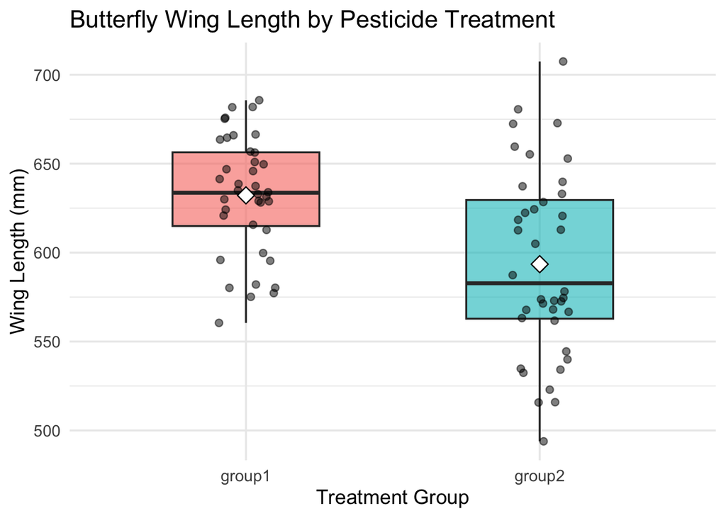

```r
ggplot(butterflies, aes(x = Group, y = WingLength, fill = Group)) +
  geom_boxplot(alpha = 0.6, width = 0.5, outlier.shape = NA) +
  geom_jitter(width = 0.1, alpha = 0.5, size = 2, color = "black") +
  stat_summary(fun = mean, geom = "point",
               shape = 23, size = 4, fill = "white", color = "black") +
  labs(
    title = "Butterfly Wing Length by Pesticide Treatment",
    x = "Treatment Group",
    y = "Wing Length (mm)",
    fill = "Group"
  ) +
  theme_minimal(base_size = 14) +
  theme(legend.position = "none")
```

#### Q5. Summary paragraph / Párrafo de resumen (40pts) - Write one concise paragraph summarizing your research objective, methods, statistical results, and interpretation of the findings, including whether the observed difference is statistically significant and biologically meaningful.

##### Interpretation: The results indicate a statistically significant difference in wing length between the two groups. Because the pesticide-treated butterflies had significantly shorter wings, 40mm on average, this finding is biologically meaningful. Shorter wing length in butterflies is often associated with reduced flight performance, which could negatively impact their ability to forage, find mates, and disperse. Conclusively, the data suggests that larval exposure to pesticides has a detrimental effect on butterfly development.